# 데이터분석(10.27)

```python
import pandas as pd
import numpy as np
import seaborn as sns
import matplotlib.pyplot as plt

from matplotlib import font_manager, rc
%matplotlib inline
from matplotlib import cm

# 한글 폰트
import platform
your_os = platform.system()
if your_os == 'Linux':
    rc('font', family='NanumGothic')
elif your_os == 'Windows':
    ttf = "c:/Windows/Fonts/malgun.ttf"
    font_name = font_manager.FontProperties(fname=ttf).get_name()
    rc('font', family=font_name)
elif your_os == 'Darwin':
    rc('font', family='AppleGothic')
rc('axes', unicode_minus=False)

pd.set_option('max_columns', 100, 'max_rows', 20)
```

#### 데이터 불러오기

```python
# 생활인구 정보
population_data = pd.read_csv('./Data/서울시 우리마을가게 상권분석서비스(상권-생활인구)_수정본.csv')
population_data = population_data.iloc[:, 1:]

# 추정 매출
buy_data = pd.read_csv('./Data/서울시 우리마을가게 상권분석서비스(상권-추정매출)_수정본.csv')
buy_data = buy_data.set_index('Unnamed: 0')

year_month = []
for i in range(buy_data.shape[0]):
    year_month.append(str(buy_data['기준_년_코드'].iloc[i]) + '-' + str(buy_data['기준_분기_코드'].iloc[i]))

buy_data['년-분기'] = year_month

# 집계시설 정보
facility_data = pd.read_csv('./Data/서울시 우리마을가게 상권분석서비스(상권-집객시설).csv', encoding = 'cp949')
facility_data = facility_data.query('기준_년_코드 >=2016') ## buy_data와 시점 맞추기 위해 query문(2016년 이후)

year_month = []
for i in range(facility_data.shape[0]):
    year_month.append(str(facility_data['기준_년_코드'].iloc[i]) + '-' + str(facility_data['기준_분기_코드'].iloc[i]))

facility_data['년-분기'] = year_month
facility_data  = facility_data.fillna(0)

# 상권변화 지표 정보
ca_change_data = pd.read_csv('./Data/서울시 우리마을가게 상권분석서비스(상권-상권변화지표).csv', encoding = 'cp949')

year_month = []
for i in range(ca_change_data.shape[0]):
    year_month.append(str(ca_change_data['기준_년_코드'].iloc[i]) + '-' + str(ca_change_data['기준_분기_코드'].iloc[i]))

ca_change_data['년-분기'] = year_month


ca_change_data = ca_change_data.query('기준_년_코드 > =2016') ## buy_data와 시점 맞추기 위해 query문(2016년 이후)
```

#### 추정 매출 속에서 분기별 전체 매출 금액 / 건수의 변화(sum)

- 2019년 1~2분기 전체 매출 금액이 급락하는 것을 확인 / 이후 3-4분기 다시 회복
- 2019년 1-2분기 전체 매출 건수는 급락하였지만 절대적인 건수에 대한 다른 분기(2020-1분기) 대비해서 매출금액은 상대적으로 적은 것을 확인

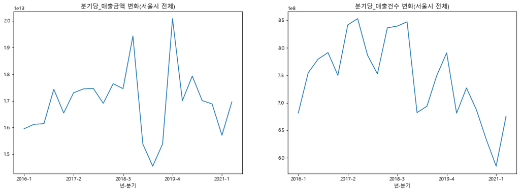

```python
fig, ax = plt.subplots(1,2, figsize = (18,6))

buy_data.groupby('년-분기')['분기당_매출_금액'].sum().plot(ax = ax[0], title = '분기당_매출금액 변화(서울시 전체)')
buy_data.groupby('년-분기')['분기당_매출_건수'].sum().plot(ax = ax[1], title = '분기당_매출건수 변화(서울시 전체)')
plt.show()
```

## [0] 상권별 특성 찾기

```python
# 매출 건수 Column 뽑기
buy_cnt_column = [colummn_name for colummn_name in list(buy_data.columns) if "건수" in colummn_name]
buy_cnt_byday = buy_cnt_column[3:10]   #  요일별 매출건수
buy_cnt_bytime = buy_cnt_column[10:16] #  시간대별 매출건수
buy_cnt_byweek = buy_cnt_column[1:3]   #  주중/주말별 매출건수
buy_cnt_byage = buy_cnt_column[-6:]    #  나이대별 매출건수
buy_cnt_bysex = buy_cnt_column[-8:-6]  #  성별 매출건수
```

### 1. 상권별 점포 수

```python
ca_shop_cnt = buy_data.pivot_table(index = ['상권_코드_명'], columns = ['년-분기'],
                                   values = '점포수', aggfunc = np.sum, fill_value = 0)
```

```python
# 분기별 점포 수
ca_shop_cnt['평균'] = ca_shop_cnt.mean(axis = 1).round(0)
```

### 2. 상권별 시간 + 매출건수 활용

1. 분기별로 요일 매출건수의 건수와 (분기 내에서 해당 요일이 차지하는 매출건수의 변화) 확인 EDA
   - 특별한점은 없고 / 상대적으로 일요일날 매출건수 / 비율이 적다는 것을 확인
1. (좀 더 Spicy하게) 분기별 주말 vs 주중의 매출 건수 확인 EDA

```python
def point(i):
    if i == "요일":
        val = buy_cnt_byday
    elif i == '시간':
        val = buy_cnt_bytime
    elif i == '주말':
        val = buy_cnt_byweek
    elif i == "성별":
        val = buy_cnt_bysex
    elif i == "나이":
        val = buy_cnt_byage


    buy_cnt_day_byqut = buy_data.groupby('년-분기')[val].sum()
    buy_cnt_day_byqut['분기별_매출건수_합'] = buy_cnt_day_byqut.sum(axis = 1)

    value = buy_cnt_day_byqut['분기별_매출건수_합']
    buy_cnt_day_byqut_ratio = buy_cnt_day_byqut.T.div(value).T.round(3).iloc[:,:-1]

    fig, ax = plt.subplots(2,1, figsize =(20,16))
    buy_cnt_day_byqut.iloc[:,:-1].plot(ax = ax[0], title = "분기별로 {} 매출건수의 변화".format(i))
    ax[0].legend(bbox_to_anchor=(1.0, 1.0))

    buy_cnt_day_byqut_ratio.plot(ax = ax[1], title = "분기별로 {} 매출건수의 변화(비율)".format(i))
    ax[1].legend(bbox_to_anchor=(1.0, 1.0))
    plt.show()
```

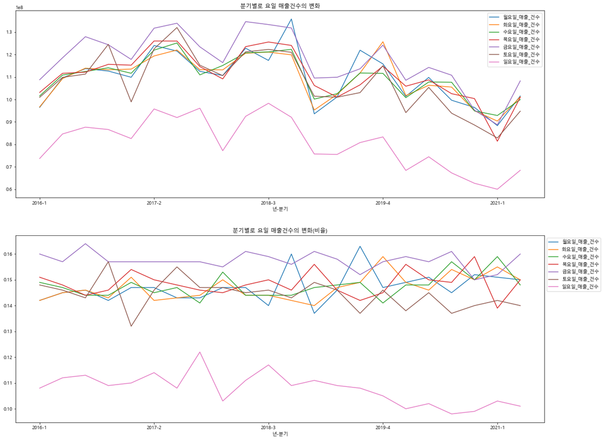

```python
#### 분기별 각 요일에 대한 매출 건수의 변화
point("요일")
```

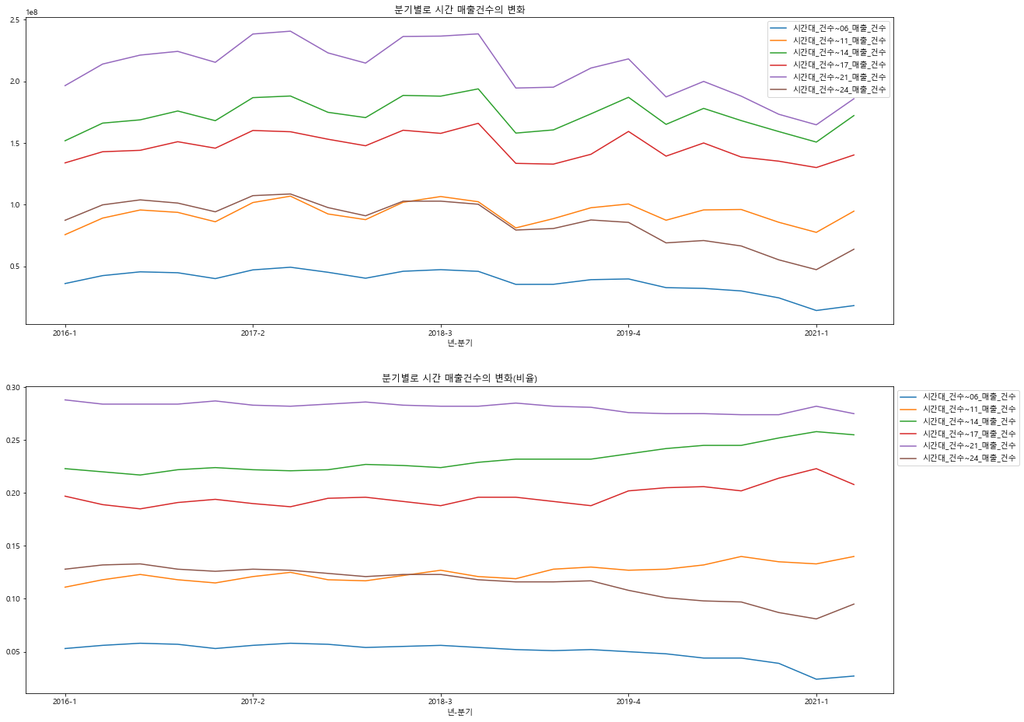

```python
#### 분기별 각 시간대에 대한 매출 건수의 변화
point("시간")
```

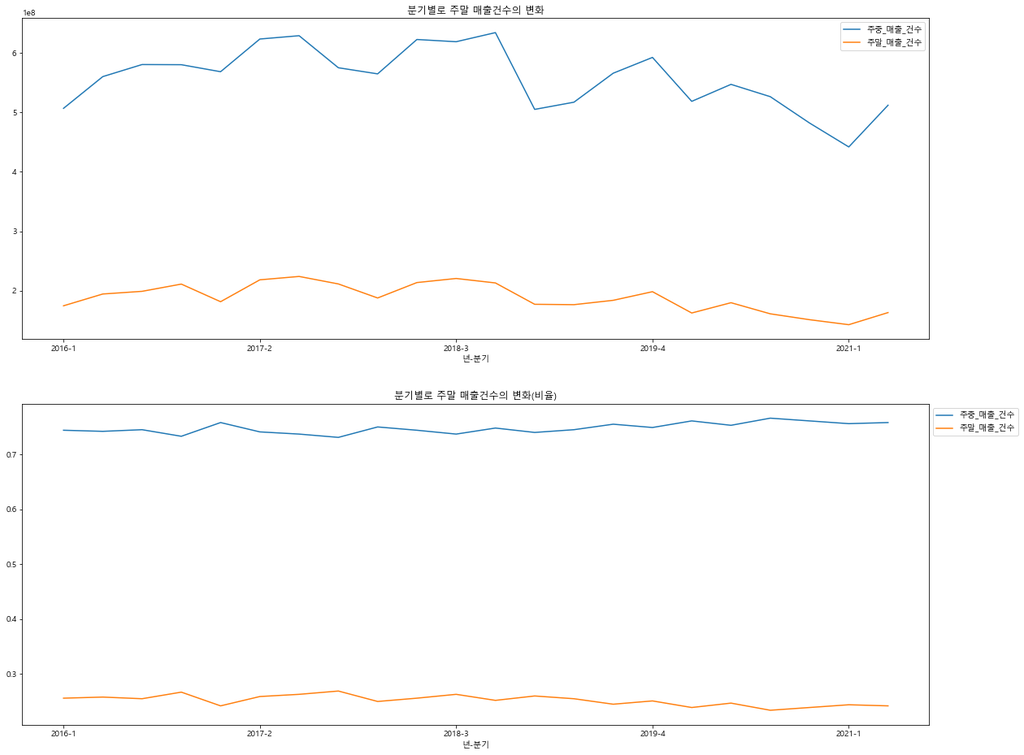

```python
#### 분기별 각 주중/주말에 대한 매출 건수의 변화
point("주말")
```

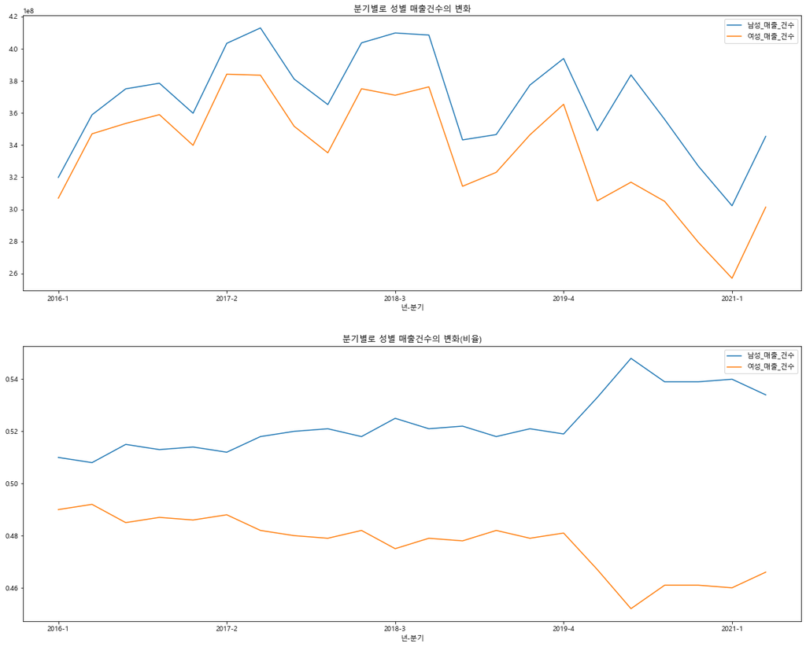

```python
#### 분기별 각 주중/주말에 대한 매출 건수의 변화
point("성별")
```

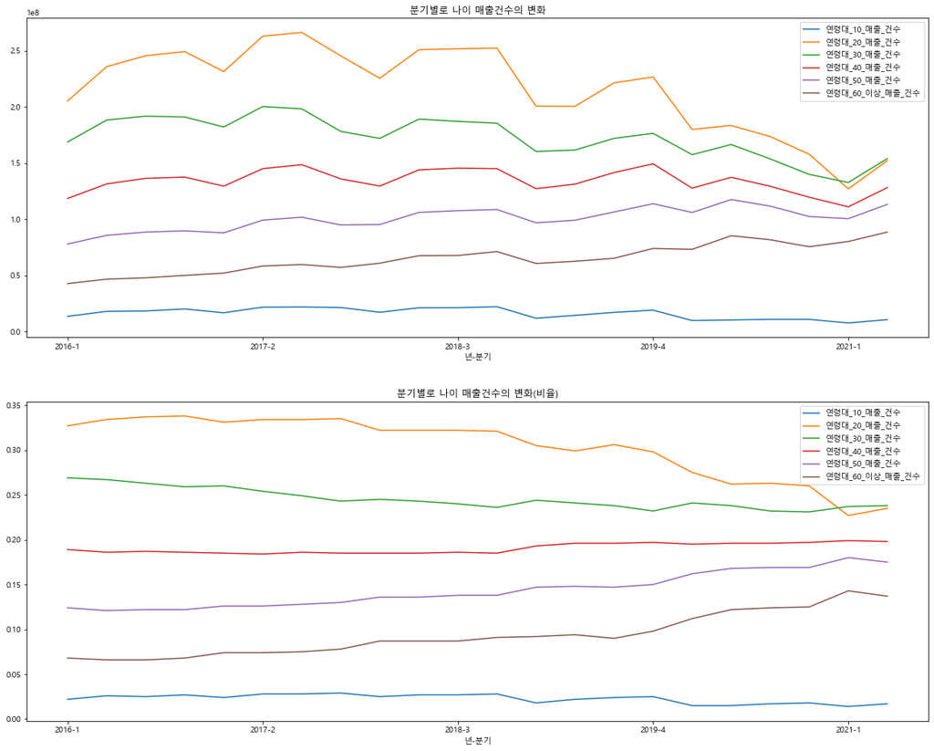

```python
#### 분기별 각 주중/주말에 대한 매출 건수의 변화
point("나이")
```

## 3. 집객시설

1. 데이터 확인 : 다른 데이터들과 다르게 추정매출 속 상권이 없는 상권이 존재
   - (추정매출에는 존재 상권 / 접객시설에는 없는 상권)
1. 집객시설의 의미: 사람을 모으는 건물(대형쇼핑몰이나 영화관)
   - 의문점: 각 상권별 집객 시설 수가 이후에 등장하는 집객시설 수를 포함시키는지 여부

```python
### 상권_코드 확인
facility_change_data_code = set(facility_data['상권_코드'].unique())
buy_data_code = set(buy_data['상권_코드'].unique())

### 추정매출에 있는 모든 상권이 상권 변화 지표에 있음을 확인할 수 잇다. (12군데: 집객시설이 없다고 표형식으로 정리)
print('추정매출에만 있는 상권 코드(접객시설 대비): ', list(buy_data_code.difference(facility_change_data_code)))
print('접객시설에만 있는 상권 코드(추정매출 대비): ', list(facility_change_data_code.difference(buy_data_code)))
print("\n")

### 분리되어있는 집개시설(교육 / 이동 등에 대한 최대값)
print("상권 中 대학교 시설이 가장 많은 곳의 개수: {}개".format(int(facility_data['대학교_수'].max())))
print("상권 中 버스터미널 시설이 가장 많은 곳의 개수: {}개".format(int(facility_data['버스_정거장_수'].max())))
print("상권 中 공항 시설이 가장 많은 곳의 개수: {}개".format(int(facility_data['공항_수'].max())))
print("상권 中 극장 시설이 가장 많은 곳의 개수: {}개".format(int(facility_data['극장_수'].max())))
```

```
추정매출에만 있는 상권 코드(접객시설 대비):  [1001312, 1001410, 1000868, 1001382, 1001417, 1001388, 1001426, 1001432, 1001370, 1001307, 1001405]
접객시설에만 있는 상권 코드(추정매출 대비):  [1001344, 1000805, 1000486, 1000489, 1001425, 1001428, 1001272, 1001305, 1001435, 1001372, 1001278, 1001311]


상권 中 대학교 시설이 가장 많은 곳의 개수: 9개
상권 中 버스터미널 시설이 가장 많은 곳의 개수: 50개
상권 中 공항 시설이 가장 많은 곳의 개수: 0개
상권 中 극장 시설이 가장 많은 곳의 개수: 90개
```

```python
### merge 용 각 상권 코드명 DF 만들기
buy_data_code = sorted(list(buy_data['상권_코드'].unique()))
buy_data_codename = sorted(list(buy_data['상권_코드_명'].unique()))
merge_ca = pd.DataFrame(data = {'상권_코드_명' : buy_data_codename})

type_code = buy_data.drop_duplicates('상권_코드_명')[['상권_코드_명','상권_구분_코드_명']].reset_index().iloc[:,1:]
merge_ca = pd.merge(merge_ca, type_code, on = '상권_코드_명', how = 'left')
```

```python
facility_data
```

|  | 기준_년_코드 | 기준_분기_코드 | 상권_구분_코드 | 상권_구분_코드_명 | 상권_코드 | 상권_코드_명 | 집객시설_수 | 관공서_수 | 은행_수 | 종합병원_수 | 일반_병원_수 | 약국_수 | 유치원_수 | 초등학교_수 | 중학교_수 | 고등학교_수 | 대학교_수 | 백화점_수 | 슈퍼마켓_수 | 극장_수 | 숙박_시설_수 | 공항_수 | 철도_역_수 | 버스_터미널_수 | 지하철_역_수 | 버스_정거장_수 | 년-분기 |
| --- | --- | --- | --- | --- | --- | --- | --- | --- | --- | --- | --- | --- | --- | --- | --- | --- | --- | --- | --- | --- | --- | --- | --- | --- | --- | --- | --- |
| 0 | 2021 | 2 | D | 발달상권 | 1001175 | 서울 강동구 고덕역 | 65 | 1.0 | 5.0 | 0.0 | 0.0 | 17.0 | 1.0 | 0.0 | 0.0 | 0.0 | 0.0 | 0.0 | 0.0 | 0.0 | 0.0 | 0.0 | 0.0 | 0.0 | 1.0 | 4.0 | 2021-2 |
| 1 | 2021 | 2 | D | 발달상권 | 1001177 | 서울 중구 약수역_2 | 24 | 0.0 | 2.0 | 0.0 | 0.0 | 4.0 | 0.0 | 0.0 | 0.0 | 0.0 | 0.0 | 0.0 | 0.0 | 0.0 | 0.0 | 0.0 | 0.0 | 0.0 | 0.0 | 1.0 | 2021-2 |
| 2 | 2021 | 2 | D | 발달상권 | 1001195 | 왕십리역_2 | 25 | 0.0 | 1.0 | 0.0 | 0.0 | 1.0 | 0.0 | 1.0 | 0.0 | 0.0 | 0.0 | 0.0 | 0.0 | 0.0 | 0.0 | 0.0 | 0.0 | 0.0 | 0.0 | 0.0 | 2021-2 |
| 3 | 2021 | 2 | D | 발달상권 | 1001198 | 서울 강서구 송정역 | 32 | 1.0 | 2.0 | 0.0 | 0.0 | 3.0 | 0.0 | 1.0 | 0.0 | 0.0 | 0.0 | 0.0 | 0.0 | 0.0 | 0.0 | 0.0 | 0.0 | 0.0 | 1.0 | 8.0 | 2021-2 |
| 4 | 2021 | 2 | D | 발달상권 | 1001205 | 동대문역사문화공원역 | 39 | 1.0 | 0.0 | 0.0 | 0.0 | 1.0 | 0.0 | 0.0 | 0.0 | 0.0 | 0.0 | 0.0 | 0.0 | 0.0 | 2.0 | 0.0 | 0.0 | 0.0 | 0.0 | 4.0 | 2021-2 |
| ... | ... | ... | ... | ... | ... | ... | ... | ... | ... | ... | ... | ... | ... | ... | ... | ... | ... | ... | ... | ... | ... | ... | ... | ... | ... | ... | ... |
| 31786 | 2016 | 1 | A | 골목상권 | 1000513 | 남부순환로40길 | 12 | 1.0 | 0.0 | 0.0 | 0.0 | 3.0 | 0.0 | 0.0 | 0.0 | 0.0 | 0.0 | 0.0 | 0.0 | 0.0 | 0.0 | 0.0 | 0.0 | 0.0 | 0.0 | 1.0 | 2016-1 |
| 31787 | 2016 | 1 | D | 발달상권 | 1001148 | 목동사거리 | 19 | 0.0 | 1.0 | 0.0 | 0.0 | 2.0 | 0.0 | 0.0 | 0.0 | 0.0 | 0.0 | 0.0 | 0.0 | 0.0 | 0.0 | 0.0 | 0.0 | 0.0 | 0.0 | 2.0 | 2016-1 |
| 31788 | 2016 | 1 | A | 골목상권 | 1000626 | 구로동로15길 | 3 | 0.0 | 0.0 | 0.0 | 0.0 | 0.0 | 1.0 | 0.0 | 0.0 | 0.0 | 0.0 | 0.0 | 0.0 | 0.0 | 0.0 | 0.0 | 0.0 | 0.0 | 0.0 | 1.0 | 2016-1 |
| 31789 | 2016 | 1 | D | 발달상권 | 1001194 | 서울 강서구 발산역 | 33 | 0.0 | 3.0 | 0.0 | 1.0 | 4.0 | 0.0 | 0.0 | 0.0 | 0.0 | 0.0 | 1.0 | 0.0 | 0.0 | 0.0 | 0.0 | 0.0 | 0.0 | 0.0 | 15.0 | 2016-1 |
| 31790 | 2016 | 1 | A | 골목상권 | 1000637 | 구로중앙로7길 | 22 | 0.0 | 0.0 | 0.0 | 0.0 | 5.0 | 0.0 | 0.0 | 0.0 | 0.0 | 0.0 | 0.0 | 0.0 | 0.0 | 0.0 | 0.0 | 0.0 | 0.0 | 0.0 | 4.0 | 2016-1 |

31791 rows × 27 columns

#### 3-1 상권별 집객 시설 개수(전체 개수 / 분기)

- 해당 기간동안 해당 싱권의 집객 시설이 어느정도 있는지 (어느 상권에 집객 시설이 몰려있는지 확인)
1. 상권별 편차가 심함
   - 접객시설의 평균: 관광특구(앞도적으로 높음) > 발달상권

```python
### 분기별 집객시설의 변화표
fa_data_cnt = facility_data.pivot_table(columns = ['년-분기'], index = '상권_코드_명', values = '집객시설_수',
                                        aggfunc = 'sum', fill_value = 0)
fa_data_cnt['집객시설_평균수'] = fa_data_cnt.mean(axis = 1).round(2)
display(fa_data_cnt.head(1))

### 상권별 집객 시설 평균
fa_data_avgcnt = fa_data_cnt.reset_index()[['상권_코드_명','집객시설_평균수']]
facility_data_ca = pd.merge(merge_ca, fa_data_avgcnt, on ="상권_코드_명", how = 'left').fillna(0)

display(facility_data_ca.head(1))
```

| 년-분기 상권_코드_명 | 2016-1 | 2016-2 | 2016-3 | 2016-4 | 2017-1 | 2017-2 | 2017-3 | 2017-4 | 2018-1 | 2018-2 | 2018-3 | 2018-4 | 2019-1 | 2019-2 | 2019-3 | 2019-4 | 2020-1 | 2020-2 | 2020-3 | 2020-4 | 2021-1 | 2021-2 | 집객시설_평균수 |
| --- | --- | --- | --- | --- | --- | --- | --- | --- | --- | --- | --- | --- | --- | --- | --- | --- | --- | --- | --- | --- | --- | --- | --- |
| 가락시장 | 22 | 22 | 20 | 20 | 21 | 21 | 21 | 21 | 32 | 32 | 32 | 32 | 32 | 32 | 32 | 32 | 32 | 32 | 32 | 32 | 32 | 21 | 27.5 |

|  | 상권_코드_명 | 상권_구분_코드_명 | 집객시설_평균수 |
| --- | --- | --- | --- |
| 0 | 가락시장 | 발달상권 | 27.5 |

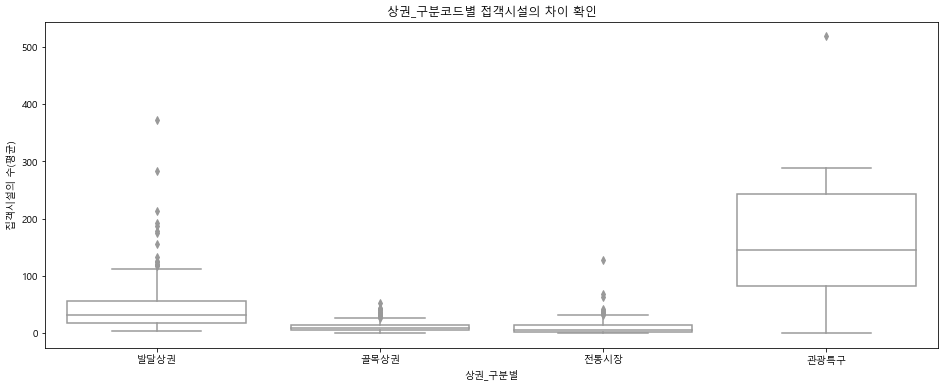

```python
fig, ax = plt.subplots(figsize=(16, 6))
sns.boxplot(x="상권_구분_코드_명", y="집객시설_평균수", data = facility_data_ca, color='white')
ax.set_xlabel('상권_구분별')
ax.set_ylabel('집객시설의 수(평균)')
ax.set_title('상권_구분코드별 접객시설의 차이 확인')
plt.show()
```

#### 3 - 2. 상권별 세부 집객 시설 항목 개수 확인

1. 가정: 각 상권별 특정 집객 시설 집중 항목들이 있을 것으로 생각
2. 문제점: 집객시설의 절대적인 수치를 완화하고 싶어서, 상대적인 비율을 계산하고 싶었지만 (집객시설_수: 해당 영역을 포함하는지 여부를 모름)

```python
#### 세부 집객 시설별 수 확인을 위해 Column 명 정의
facility_column = [colummn_name for colummn_name in list(facility_data.columns) if "수" in colummn_name]
facility_column = facility_column[1:]

point_column = ['년-분기','상권_코드_명']

facility_school_column = [colummn_name for colummn_name in facility_column if "학교" in colummn_name]
facility_transportation_column = facility_column[-5:]
facility_hospital_column = facility_column[2:5]
facility_ohter_column = facility_column[:2] + facility_column[10:13]
```

```python
facility_school_column
```

```
['초등학교_수', '중학교_수', '고등학교_수', '대학교_수']
```

```python
### 세부 집격 시설별 평균
variance_name_list = ['교육시설_평균수','교통수단시설_평균수','병원시설_평균수','편의시설_평균수']
columns_list = [facility_school_column, facility_transportation_column, facility_hospital_column, facility_ohter_column ]

for num, column in enumerate(columns_list):
    data = facility_data[point_column+ column]

    column_name = variance_name_list[num]
    data[column_name] = data.sum(axis = 1)
    data_cnt = data.pivot_table(columns = ['년-분기'], index = '상권_코드_명', values = column_name, aggfunc = 'sum', fill_value = 0)

    data_cnt[column_name] = data_cnt.mean(axis = 1).round(2)

    data_cnt = data_cnt.reset_index()[['상권_코드_명',column_name]]

    if num == 0:
        facility_detail_ca = pd.merge(facility_data_ca, data_cnt, on ="상권_코드_명", how = 'left').fillna(0)
    else:
        facility_detail_ca = pd.merge(facility_detail_ca, data_cnt, on ="상권_코드_명", how = 'left').fillna(0)
```

```python
facility_detail_ca
```

|  | 상권_코드_명 | 상권_구분_코드_명 | 집객시설_평균수 | 교육시설_평균수 | 교통수단시설_평균수 | 병원시설_평균수 | 편의시설_평균수 |
| --- | --- | --- | --- | --- | --- | --- | --- |
| 0 | 가락시장 | 발달상권 | 27.50 | 0.0 | 6.23 | 2.95 | 11.41 |
| 1 | 가로공원로58길 | 골목상권 | 3.18 | 0.0 | 0.00 | 1.00 | 0.00 |
| 2 | 가로공원로76가길 | 골목상권 | 8.14 | 0.0 | 0.00 | 1.00 | 0.00 |
| 3 | 가로공원로80길 | 골목상권 | 3.41 | 0.0 | 0.00 | 2.00 | 0.00 |
| 4 | 가리봉시장 | 전통시장 | 2.14 | 0.0 | 0.00 | 1.00 | 0.00 |
| ... | ... | ... | ... | ... | ... | ... | ... |
| 1475 | 휘경로2길 | 골목상권 | 15.09 | 0.0 | 1.91 | 1.82 | 0.00 |
| 1476 | 휘경로3길 | 골목상권 | 15.73 | 0.0 | 1.73 | 4.73 | 0.18 |
| 1477 | 흑석로13길 | 골목상권 | 8.00 | 0.0 | 0.68 | 0.00 | 0.82 |
| 1478 | 흑석로9길 | 골목상권 | 5.95 | 0.0 | 3.09 | 0.00 | 0.00 |
| 1479 | 흑석시장 | 전통시장 | 24.82 | 0.0 | 3.18 | 4.77 | 3.91 |

1480 rows × 7 columns

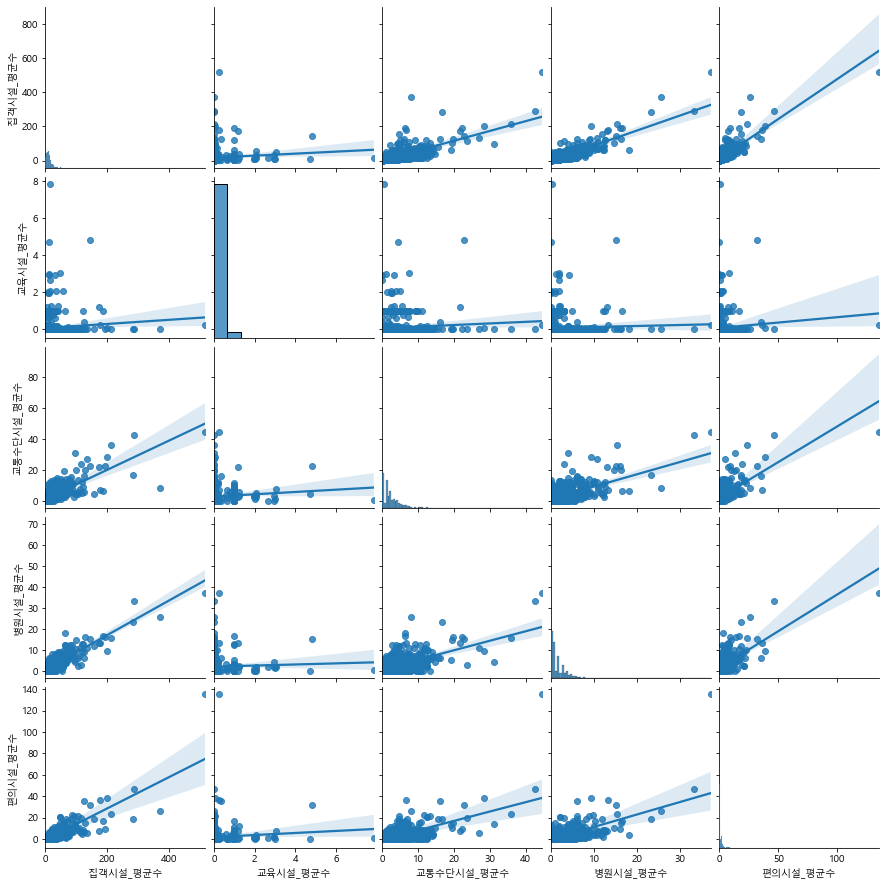

```python
sns.pairplot(facility_detail_ca , vars=list(facility_detail_ca.columns)[2:], kind='reg')
plt.show()
```

```python
for i in variance_name_list:
    print('{}의 평균: {} / 최대값: {}'.format(i, facility_detail_ca[i].mean(), facility_detail_ca[i].max()))
```

```
교육시설_평균수의 평균: 0.07346621621621618 / 최대값: 7.86
교통수단시설_평균수의 평균: 2.7777500000000046 / 최대값: 44.64
병원시설_평균수의 평균: 1.9611756756756746 / 최대값: 37.09
편의시설_평균수의 평균: 1.8187094594594593 / 최대값: 135.59
```

```python
from sklearn.preprocessing import RobustScaler
robustScaler = RobustScaler()
x_scaled = robustScaler.fit_transform(facility_detail_ca.iloc[:,3:])
```

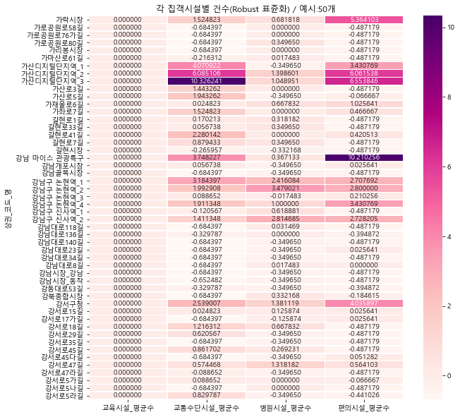

```python
data_result_norm = pd.DataFrame(x_scaled, columns = list(facility_detail_ca.columns)[3:], index = facility_detail_ca.index)
data_result_norm = pd.concat([facility_detail_ca.iloc[:,:2],data_result_norm], axis = 1)

plt.figure(figsize = (10,10))
sns.heatmap(data_result_norm.set_index('상권_코드_명').head(50)[variance_name_list], annot=True, fmt='f', linewidths=.5,
                       cmap='RdPu')
plt.title('각 집객시설별 건수(Robust 표쥰화) / 예시:50개')
plt.show()
```

#### 가정: 지하철역 근처 혹은 관광특구에 집객시설이 많이 몰려있을 것이다.

- 관광특구는 어느정도 맞는 가설이지만 지하철역은 역별로 편차가 심함(같은 역이어도 상권번호에 따라서 달라짐

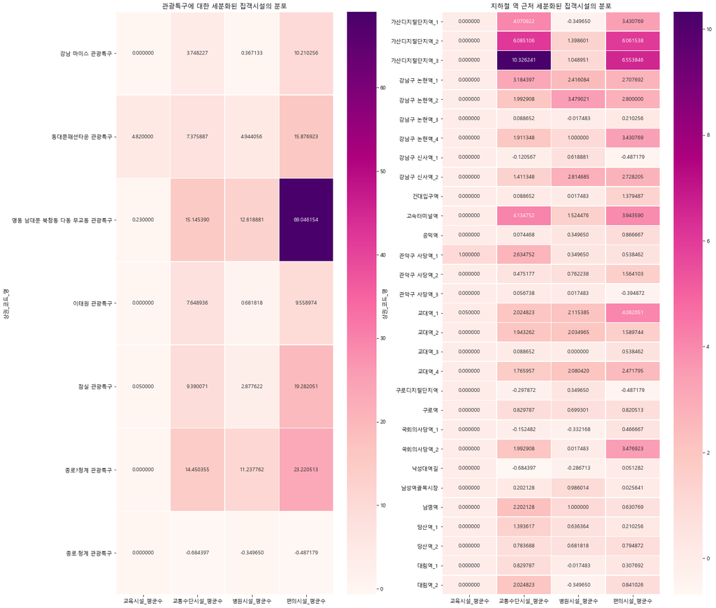

```python
station_list = [colummn_name for colummn_name in list(data_result_norm['상권_코드_명']) if "역" in colummn_name]
tourism_list = list(data_result_norm[data_result_norm['상권_구분_코드_명'] == "관광특구"]['상권_코드_명'])

fig, ax = plt.subplots(1,2, figsize = (20,20))

sns.heatmap(data_result_norm.query('상권_코드_명 in @tourism_list').set_index('상권_코드_명')[variance_name_list],
            annot=True, fmt='f', linewidths=.5, cmap='RdPu', ax = ax[0])
ax[0].set_title('관광특구에 대한 세분화된 집객시설의 분포')

sns.heatmap(data_result_norm.query('상권_코드_명 in @station_list').set_index('상권_코드_명').head(30)[variance_name_list],
            annot=True, fmt='f', linewidths=.5, cmap='RdPu', ax = ax[1])
ax[1].set_title('지하철 역 근처 세분화된 집객시설의 분포')
plt.show()
```

```python
data_result_norm
```

|  | 상권_코드_명 | 상권_구분_코드_명 | 교육시설_평균수 | 교통수단시설_평균수 | 병원시설_평균수 | 편의시설_평균수 |
| --- | --- | --- | --- | --- | --- | --- |
| 0 | 가락시장 | 발달상권 | 0.0 | 1.524823 | 0.681818 | 5.364103 |
| 1 | 가로공원로58길 | 골목상권 | 0.0 | -0.684397 | 0.000000 | -0.487179 |
| 2 | 가로공원로76가길 | 골목상권 | 0.0 | -0.684397 | 0.000000 | -0.487179 |
| 3 | 가로공원로80길 | 골목상권 | 0.0 | -0.684397 | 0.349650 | -0.487179 |
| 4 | 가리봉시장 | 전통시장 | 0.0 | -0.684397 | 0.000000 | -0.487179 |
| ... | ... | ... | ... | ... | ... | ... |
| 1475 | 휘경로2길 | 골목상권 | 0.0 | -0.007092 | 0.286713 | -0.487179 |
| 1476 | 휘경로3길 | 골목상권 | 0.0 | -0.070922 | 1.304196 | -0.394872 |
| 1477 | 흑석로13길 | 골목상권 | 0.0 | -0.443262 | -0.349650 | -0.066667 |
| 1478 | 흑석로9길 | 골목상권 | 0.0 | 0.411348 | -0.349650 | -0.487179 |
| 1479 | 흑석시장 | 전통시장 | 0.0 | 0.443262 | 1.318182 | 1.517949 |

1480 rows × 6 columns

## 2. 서울시 상권변화 지표 설명

- 상권변화지표 : 상업공간의 변화를 생존한 사업체의 평균 영업기간과 폐업한 사업체의 평균 영업기간을 기준으로 4개 등급으로나눈 지표 (생존한 사업체의 평균영업기간 (H: high, L: Low)과 폐업한 사업체의 평균영업기간 (H: high, L: Low)을 기준으로 4분할)
1. LL : 다이나믹
   - 도시 재생 / 신규 개발 상권
   - 창업 진출입시 주의가 필요한 상권
   - (기준 시점) 서울시 생존한 사업체 평균 영업기간보다 상대적으로 낮음(해당 상권의 생존한 사업체의 평균 영업기간이 낮음)
   - (기준 시점) 서울시 폐업한 사업체 평균 영업기간보다 상대적으로 낮음(해당 상권의 폐업한 사업체의 평균 영업기간이 낮음)
2. LH: 상권확장
   - 경쟁력 있는 신규 창업 우위 상권
   - (기존 시점) 서울시 생존한 사업체 평균 영업기간보다 상대적으로 낮음(해당 상권의 생존한 사업체의 평균 영업기간이 낮음)
   - (기존 시점) 서울시 폐업한 사업체 평균 영업기간보다 상대적으로 높음(해당 상권의 폐업한 사업체의 평균 영업기간이 높음)
3. HL: 상권 축소
   - 경쟁력 있는 기존 업체 우위 상권
   - (기존 시점) 서울시 생존한 사업체 평균 영업기간보다 상대적으로 높음(해당 상권의 생존한 사업체의 평균 영업기간이 높음)
   - (기존 시점) 서울시 페업한 사업체 평균 영업기간보다 상대적으로 낮음(해당 상권의 생존한 사업체의 평균 영업기간이 낮음)
4. HH: 정체
   - 창업 진출입시 세심한 주의 상권
   - (기존 시점) 서울시 생존한 사업체 평균 영업기간보다 상대적으로 높음(해당 상권의 생존한 사업체의 평균 영업기간이 높음)
   - (기존 시점) 서울시 페업한 사업체 평균 영업기간보다 상대적으로 높음(해당 상권의 생존한 사업체의 평균 영업기간이 높음)

```python
### 상권_코드 확인
ca_change_data_code = set(ca_change_data['상권_코드'].unique())
buy_data_code = set(buy_data['상권_코드'].unique())

### 추정매출에 있는 모든 상권이 상권 변화 지표에 있음을 확인할 수 잇다.
print('추정매출 지표의 상권 코드(상권변화 지표): ', list(buy_data_code.difference(ca_change_data_code)))
print('상권변화 지표의 상권 코드(추정매출 지표): ', list(ca_change_data_code.difference(buy_data_code)))
```

```
추정매출 지표의 상권 코드(상권변화 지표):  []
상권변화 지표의 상권 코드(추정매출 지표):  [1001344, 1001472, 1000805, 1000486, 1001317, 1001435, 1000489, 1001389, 1001425, 1001428, 1001272, 1001305, 1001434, 1001401, 1001372, 1001278, 1001311]
```

#### 해석

- 전반적인 서울시 분기별 폐업 사업체의 (폐업 전) 평균 영업 개월은 지속적 증가 >> (가정) 장기 운영했던 사업체가 폐업되었을 것이라 추측
- 전반적인 서울시 분기별 운영 사업체의 평균 영업 개월 지속적 증가 >> 장기 운영했던 사업체가 지속적으로 사업을 유지

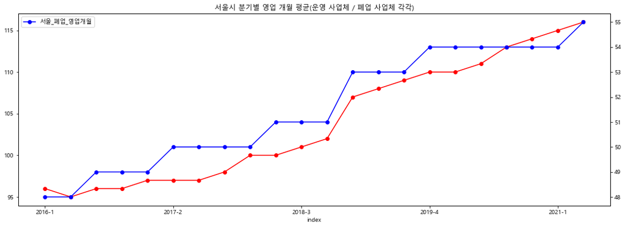

```python
seoul_avg_survive = list(ca_change_data.drop_duplicates(['년-분기'])['서울_운영_영업_개월_평균'])
seoul_avg_close = list(ca_change_data.drop_duplicates(['년-분기'])['서울_폐업_영업_개월_평균'])
seoul_time = list(ca_change_data.drop_duplicates(['년-분기'])['년-분기'])
value = pd.DataFrame(index = seoul_time, data = {'서울_운영_영업개월' : seoul_avg_survive, '서울_폐업_영업개월' : seoul_avg_close})
value = value.reset_index().sort_values(by = 'index', ascending = True).set_index('index')

# plot 그리기 [서울시 사업체 평균 영업기간 변화 확인]
fig, ax = plt.subplots(figsize = (18,6))
ax2 = ax.twinx()

value['서울_운영_영업개월'].plot(ax = ax, color = 'r', marker = 'o')
value['서울_폐업_영업개월'].plot(ax = ax2, color = 'b', marker = 'o')

ax.set_title('서울시 분기별 영업 개월 평균(운영 사업체 / 폐업 사업체 각각)')

plt.legend()
ax2.legend(loc=0)
plt.show()
```

#### (5) 서울시 상권변화 지표 활용(각 상권별 상권 지표 횟수)

- 해당 상권이 지표상으로 어느쪽에 속하는지

```python
### Feature: 각 상권별 2016년 ~ 2021년 2분기까지 상권변화 지표 횟수
change_data = ca_change_data.pivot_table(index = '상권_코드_명', columns = '상권_변화_지표_명', values = '상권_변화_지표',
                                         aggfunc = 'count', fill_value =0)
display(change_data.head(5))
```

| 상권_변화_지표_명 상권_코드_명 | 다이나믹 | 상권축소 | 상권확장 | 정체 |
| --- | --- | --- | --- | --- |
| 가락시장 | 0 | 0 | 12 | 10 |
| 가로공원로58길 | 0 | 21 | 0 | 1 |
| 가로공원로76가길 | 12 | 10 | 0 | 0 |
| 가로공원로80길 | 22 | 0 | 0 | 0 |
| 가리봉시장 | 0 | 0 | 0 | 22 |

```python
# 각 상권별 운영하는 영업점포에 평균 운영 개월수의 분기 변화(현재 진행 중)
ca_avg_survive = ca_change_data.pivot_table(index = '상권_코드_명', columns = '년-분기',
                                           values = '운영_영업_개월_평균', aggfunc = np.sum, fill_value = 0).T
survive_begin = ca_avg_survive.iloc[0,:]
ca_avg_survive_rateofchange = ca_avg_survive.div(survive_begin).sub(1).round(2).T
ca_avg_survive_rateofchange['변화율_최대값'] = ca_avg_survive_rateofchange.max(axis = 1)
ca_avg_survive_rateofchange['변화율_최소값'] = ca_avg_survive_rateofchange.min(axis = 1)

# 각 상권별 폐업한 영업점포에 (영업하는 과정) 평균 운영 개월수의 분기 변화(현재 진행 중)
ca_avg_close = ca_change_data.pivot_table(index = '상권_코드_명', columns = '년-분기',
                                         values = '폐업_영업_개월_평균', aggfunc = np.sum, fill_value = 0).T
close_begin = ca_avg_close.iloc[0,:]
ca_avg_close_rateofchange = ca_avg_close.div(close_begin).sub(1).round(2).T
ca_avg_close_rateofchange['변화율_최대값'] = ca_avg_close_rateofchange.max(axis = 1)
ca_avg_close_rateofchange['변화율_최소값'] = ca_avg_close_rateofchange.min(axis = 1)
```

```python
ca_avg_close_rateofchange.head(2)
```

| 년-분기 상권_코드_명 | 2016-1 | 2016-2 | 2016-3 | 2016-4 | 2017-1 | 2017-2 | 2017-3 | 2017-4 | 2018-1 | 2018-2 | 2018-3 | 2018-4 | 2019-1 | 2019-2 | 2019-3 | 2019-4 | 2020-1 | 2020-2 | 2020-3 | 2020-4 | 2021-1 | 2021-2 | 변화율_최대값 | 변화율_최소값 |
| --- | --- | --- | --- | --- | --- | --- | --- | --- | --- | --- | --- | --- | --- | --- | --- | --- | --- | --- | --- | --- | --- | --- | --- | --- |
| 가락시장 | 0.0 | 0.02 | 0.04 | 0.04 | 0.04 | 0.04 | 0.05 | 0.05 | 0.05 | 0.05 | 0.07 | 0.07 | 1.75 | 1.75 | 1.69 | 1.02 | 3.73 | 3.73 | 4.04 | 4.02 | 4.02 | 4.00 | 4.04 | 0.0 |
| 가로공원로58길 | 0.0 | 0.00 | 0.02 | 0.02 | 0.02 | 0.05 | 0.05 | 0.05 | 0.05 | 0.05 | 0.07 | 0.09 | 0.19 | 0.19 | 0.19 | 0.16 | 0.23 | 0.23 | 0.23 | 0.23 | 0.26 | 0.28 | 0.28 | 0.0 |

```python
ca_change_data
```

|  | 기준_년_코드 | 기준_분기_코드 | 상권_구분_코드 | 상권_구분_코드_명 | 상권_코드 | 상권_코드_명 | 상권_변화_지표 | 상권_변화_지표_명 | 운영_영업_개월_평균 | 폐업_영업_개월_평균 | 서울_운영_영업_개월_평균 | 서울_폐업_영업_개월_평균 | 년-분기 |
| --- | --- | --- | --- | --- | --- | --- | --- | --- | --- | --- | --- | --- | --- |
| 0 | 2021 | 2 | U | 관광특구 | 1001496 | 강남 마이스 관광특구 | HH | 정체 | 131 | 64 | 116 | 55 | 2021-2 |
| 1 | 2021 | 2 | U | 관광특구 | 1001495 | 잠실 관광특구 | LL | 다이나믹 | 112 | 53 | 116 | 55 | 2021-2 |
| 2 | 2021 | 2 | U | 관광특구 | 1001494 | 종로?청계 관광특구 | HH | 정체 | 156 | 73 | 116 | 55 | 2021-2 |
| 3 | 2021 | 2 | U | 관광특구 | 1001493 | 동대문패션타운 관광특구 | HH | 정체 | 134 | 63 | 116 | 55 | 2021-2 |
| 4 | 2021 | 2 | U | 관광특구 | 1001492 | 명동 남대문 북창동 다동 무교동 관광특구 | HH | 정체 | 159 | 64 | 116 | 55 | 2021-2 |
| ... | ... | ... | ... | ... | ... | ... | ... | ... | ... | ... | ... | ... | ... |
| 32907 | 2016 | 1 | A | 골목상권 | 1000005 | 백석동길 | LL | 다이나믹 | 77 | 47 | 96 | 48 | 2016-1 |
| 32908 | 2016 | 1 | A | 골목상권 | 1000004 | 명륜길 | LH | 상권확장 | 81 | 57 | 96 | 48 | 2016-1 |
| 32909 | 2016 | 1 | A | 골목상권 | 1000003 | 돈화문로11가길 | HH | 정체 | 105 | 48 | 96 | 48 | 2016-1 |
| 32910 | 2016 | 1 | A | 골목상권 | 1000002 | 난계로27길 | HL | 상권축소 | 113 | 40 | 96 | 48 | 2016-1 |
| 32911 | 2016 | 1 | A | 골목상권 | 1000001 | 계동길 | LH | 상권확장 | 89 | 53 | 96 | 48 | 2016-1 |

32912 rows × 13 columns

#### 이후 추가적으로 진행해보고 싶은 사항: 상권별 상권변화 지표와 영업 / 폐업접포의 평균 영업 개월수의 변화 확인

#### 추가진행 (5)-1

- 각 상권변화 지표명이 과반수 이상 나온것을 해당 상관 지표라고 표시할경우
1. 다이나믹

```python
LL_ca_list = list(change_data.query('다이나믹>=12').index)
LH_ca_list = list(change_data.query('상권확장>=12').index)
HL_ca_list = list(change_data.query('상권축소>=12').index)
HH_ca_list = list(change_data.query('정체>=12').index)

change_data_cp = change_data.reset_index()

# 각 상권별 대표 상권지표 표시
change_data_cp['상권지표'] = change_data_cp['상권_코드_명'].agg(lambda x: "다이나믹" if x in LL_ca_list else "상권확장"
                                                       if x in LH_ca_list else "상권축소" if x in HL_ca_list else "정체")
```

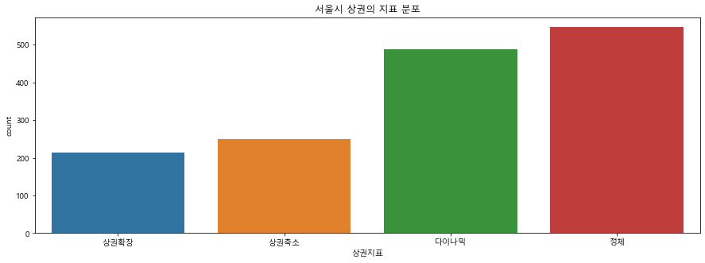

```python
import seaborn as sns
fig, axes = plt.subplots(figsize=(15,5))
sns.countplot(x='상권지표', data=change_data_cp, ax = axes)
axes.set_title('서울시 상권의 지표 분포')
plt.show()
```

만든 Feature 별 정리

- facility_data_ca: 각 상권별 집객시설의 평균값
- data_result_norm: 각 상권별 주요 집객[교통/교육/병원/기타] 시설별 평균값(Robust scaling)
- change_data : 각 상권별 상권변화 지표 지수(4 Column)